# Time Series Assignment 5

Anusha Bhat

2025-02-12

```r
library(lmtest)
library(forecast)
# load in data
df = read.csv("Gas Furnace Dataset.csv")
colnames(df) = c("GasRate", "CO2")
head(df)
```

```
##   GasRate  CO2
## 1  -0.109 53.8
## 2   0.000 53.6
## 3   0.178 53.5
## 4   0.339 53.5
## 5   0.373 53.4
## 6   0.441 53.1
```

# Question 1: Linear Regression

```r
# create lin reg model
model = lm(CO2 ~ GasRate, data = df)
summary(model)
```

```
##
## Call:
## lm(formula = CO2 ~ GasRate, data = df)
##
## Residuals:
##     Min      1Q  Median      3Q     Max
## -6.2139 -2.0642  0.0954  2.2743  6.5750
##
## Coefficients:
##             Estimate Std. Error t value Pr(>|t|)
## (Intercept)  53.4269     0.1633 327.116   <2e-16 ***
## GasRate      -1.4460     0.1523  -9.495   <2e-16 ***
## ---
## Signif. codes:  0 '***' 0.001 '**' 0.01 '*' 0.05 '.' 0.1 ' ' 1
##
## Residual standard error: 2.806 on 294 degrees of freedom
## Multiple R-squared:  0.2347, Adjusted R-squared:  0.2321
## F-statistic: 90.16 on 1 and 294 DF,  p-value: < 2.2e-16
```

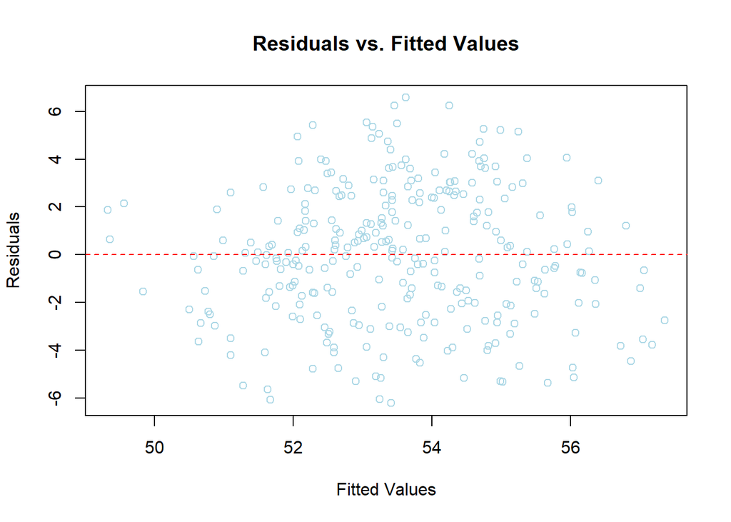

```r
# plot residuals vs. fitted values to examine the residuals

resids = residuals(model)
fitted = fitted(model)
plot(y = resids, x = fitted,
     main = "Residuals vs. Fitted Values",
     ylab = "Residuals",
     xlab = "Fitted Values", col = "Light Blue")
abline(h = 0, col = "red", lty = 2)
```

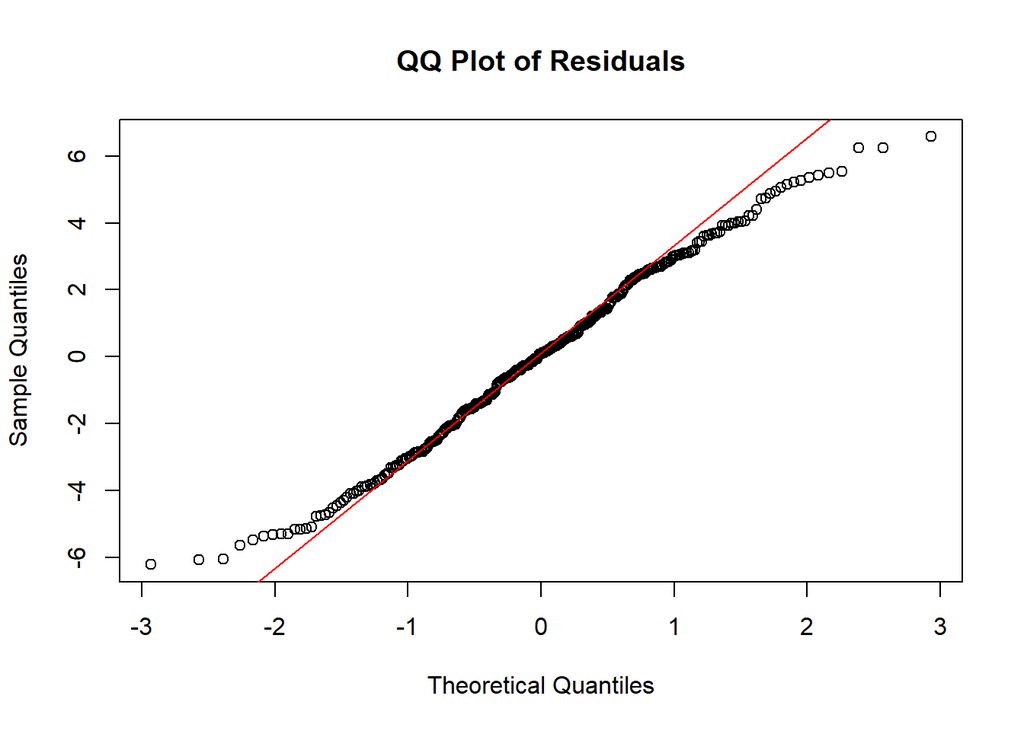

```r
qqnorm(resids, main = "QQ Plot of Residuals")
qqline(resids, col = "red")
```

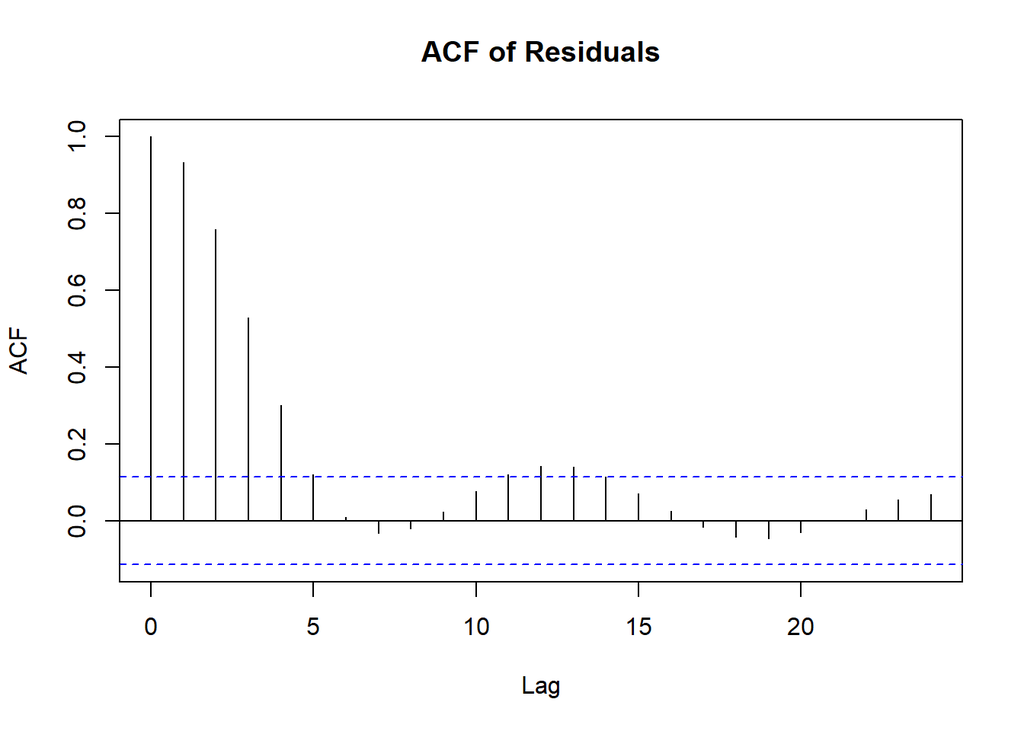

```r
# acf of residuals
acf(resids, main = "ACF of Residuals")
```

Based on the qqplot, the residuals do not deviate too far from the normal distribution. Additionally, the residuals are mostly evenly distributed and centered around 0, indicating little to no heteroscedasticity. However, the ACF plot shows some initial dependencies between the residuals, with a sharp decrease as the lags increase. This may indicate a problem with the model specification (perhaps there is a time series dependence that is not being accounted for with a linear regression), but the other model diagnostics indicate a well-specified model so we can proceed with caution.

## Question 2: Constructing ARMA models

```r
# fit the models
arma_1_0 = arima(resids, order = c(1, 0, 0))
arma_0_1 = arima(resids, order = c(0, 0, 1))
arma_1_1 = arima(resids, order = c(1, 0, 1))
arma_2_0 = arima(resids, order = c(2, 0, 0))
arma_0_2 = arima(resids, order = c(0, 0, 2))
arma_2_2 = arima(resids, order = c(2, 0, 2))
```

```r
# show the models
print("ARMA (1, 0, 0)")
```

```
## [1] "ARMA (1, 0, 0)"
```

```r
arma_1_0
```

```
##
## Call:
## arima(x = resids, order = c(1, 0, 0))
##
## Coefficients:
##          ar1  intercept
##       0.9337     0.1481
## s.e.  0.0202     0.8337
##
## sigma^2 estimated as 0.9873:  log likelihood = -419.15,  aic = 844.29
```

```r
print("ARMA (0, 0, 1)")
```

```
## [1] "ARMA (0, 0, 1)"
```

```r
arma_0_1
```

```
##
## Call:
## arima(x = resids, order = c(0, 0, 1))
##
## Coefficients:
##          ma1  intercept
##       0.9421     0.0055
## s.e.  0.0150     0.1697
##
## sigma^2 estimated as 2.268:  log likelihood = -542.27,  aic = 1090.54
```

```r
print("ARMA (1, 0, 1)")
```

```
## [1] "ARMA (1, 0, 1)"
```

```r
arma_1_1
```

```
##
## Call:
## arima(x = resids, order = c(1, 0, 1))
##
## Coefficients:
##          ar1     ma1  intercept
##       0.9137  0.7533     0.1101
## s.e.  0.0232  0.0272     0.7494
##
## sigma^2 estimated as 0.432:  log likelihood = -297.62,  aic = 603.24
```

```r
print("ARMA (2, 0,0)")
```

```
## [1] "ARMA (2, 0,0)"
```

```r
arma_2_0
```

```
##
## Call:
## arima(x = resids, order = c(2, 0, 0))
##
## Coefficients:
##          ar1      ar2  intercept
##       1.7431  -0.8658    -0.0082
## s.e.  0.0282   0.0282     0.2331
##
## sigma^2 estimated as 0.2419:  log likelihood = -212.36,  aic = 432.73
```

```r
print("ARMA (0, 0, 2)")
```

```
## [1] "ARMA (0, 0, 2)"
```

```r
arma_0_2
```

```
##
## Call:
## arima(x = resids, order = c(0, 0, 2))
##
## Coefficients:
##          ma1     ma2  intercept
##       1.5853  0.8726     0.0093
## s.e.  0.0270  0.0241     0.1842
##
## sigma^2 estimated as 0.8454:  log likelihood = -397.22,  aic = 802.43
```

```r
print("ARMA (2, 0, 2)")
```

```
## [1] "ARMA (2, 0, 2)"
```

```r
arma_2_2
```

```
##
## Call:
## arima(x = resids, order = c(2, 0, 2))
##
## Coefficients:
##          ar1      ar2     ma1     ma2  intercept
##       1.6077  -0.7500  0.4075  0.3444     0.0189
## s.e.  0.0442   0.0437  0.0641  0.0539     0.3086
##
## sigma^2 estimated as 0.1877:  log likelihood = -175.19,  aic = 362.38
```

## Question 3: ARMA Coefficients:

Essentially, all of the ar and ma coefficients are twice their standard errors in each of the models. On the other hand, the intercepts for all models are less than twice their standard errors.

## Question 4: Plotting ARMA Residuals and ACF

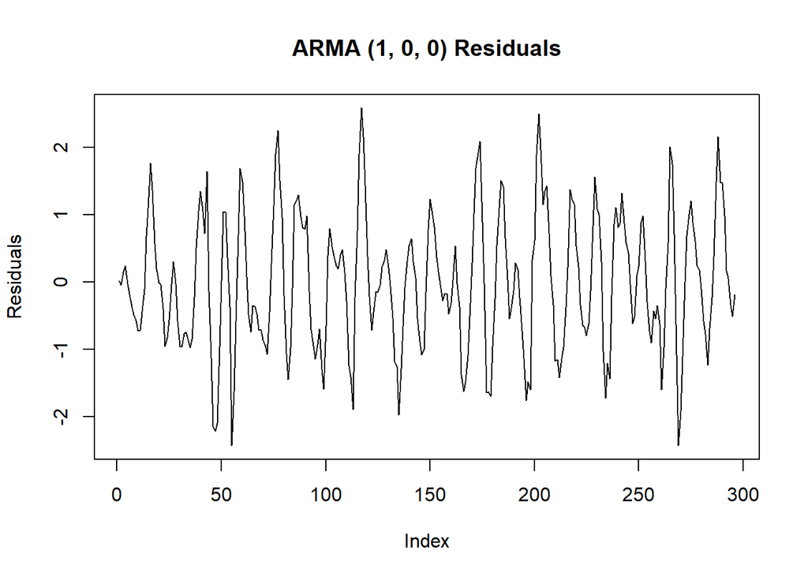

```r
# plot the residuals

plot(arma_1_0$residuals, main = "ARMA (1, 0, 0) Residuals",
     xlab = "Index",
     ylab = "Residuals", type="l")
```

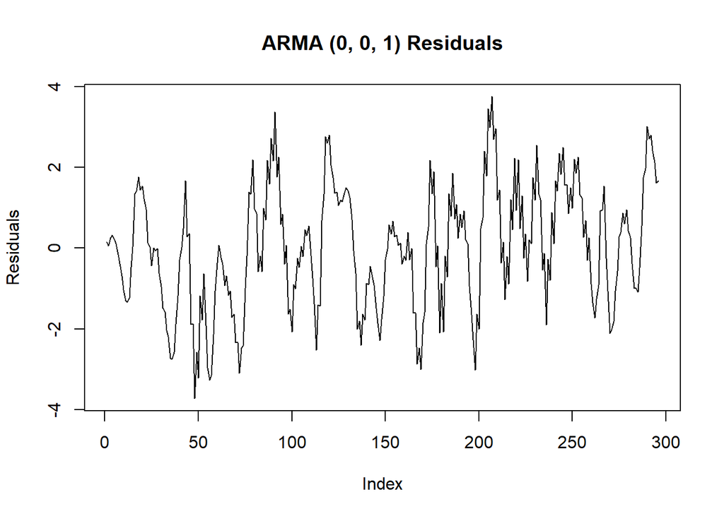

```r
plot(arma_0_1$residuals, main = "ARMA (0, 0, 1) Residuals",
     xlab = "Index",
     ylab = "Residuals", type="l")
```

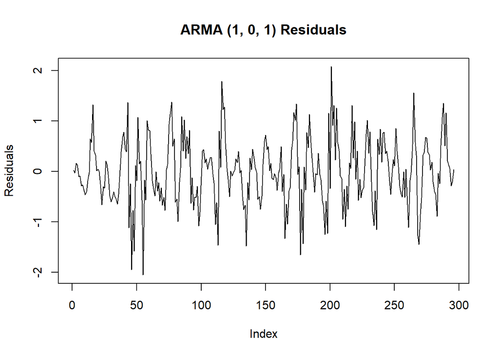

```r
plot(arma_1_1$residuals, main = "ARMA (1, 0, 1) Residuals",
     xlab = "Index",
     ylab = "Residuals", type="l")
```

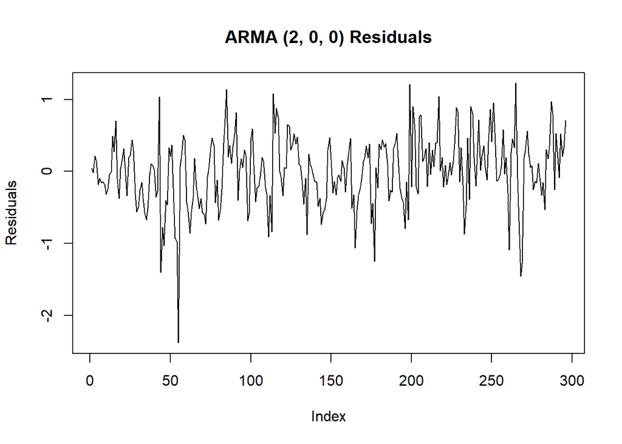

```r
plot(arma_2_0$residuals, main = "ARMA (2, 0, 0) Residuals",
     xlab = "Index",
     ylab = "Residuals", type="l")
```

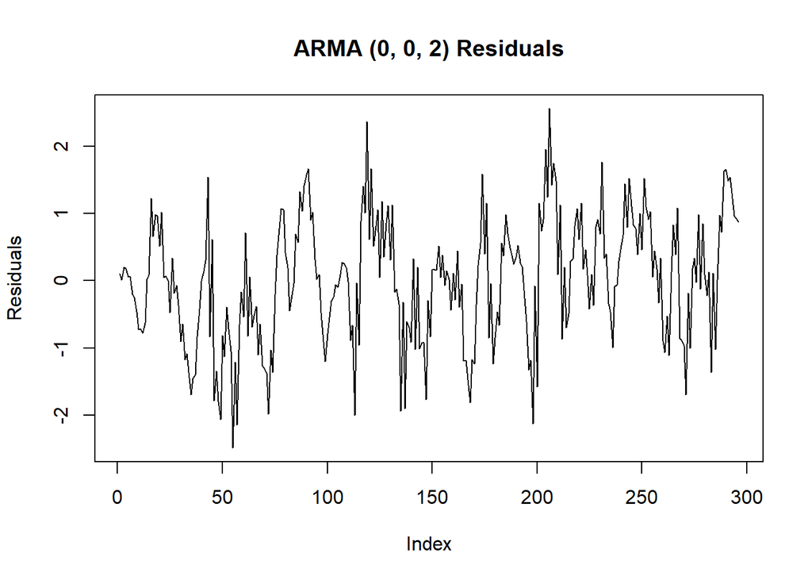

```r
plot(arma_0_2$residuals, main = "ARMA (0, 0, 2) Residuals",
     xlab = "Index",
     ylab = "Residuals", type="l")
```

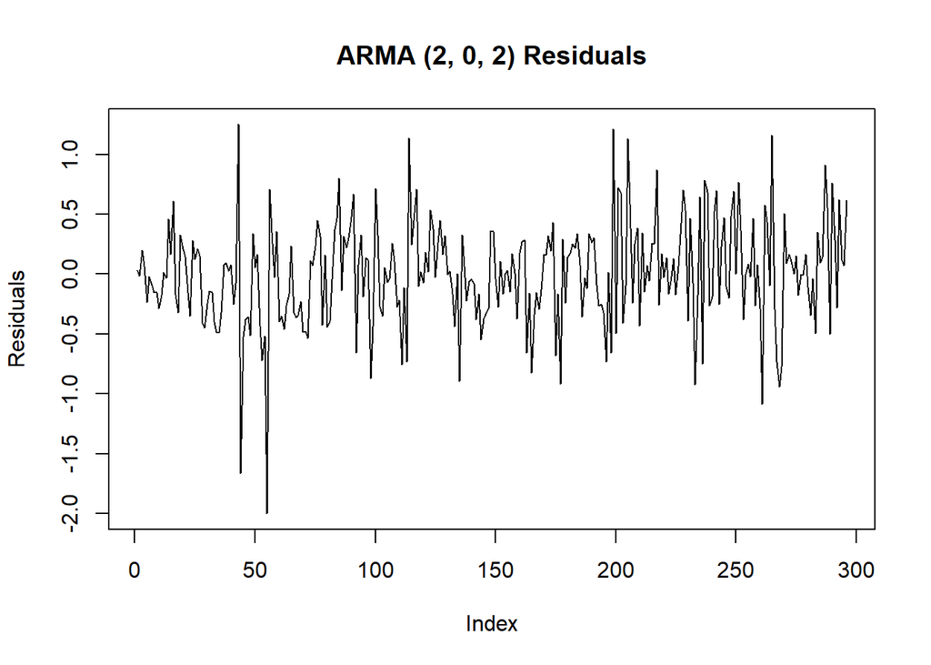

```r
plot(arma_2_2$residuals, main = "ARMA (2, 0, 2) Residuals",
     xlab = "Index",
     ylab = "Residuals", type="l")
```

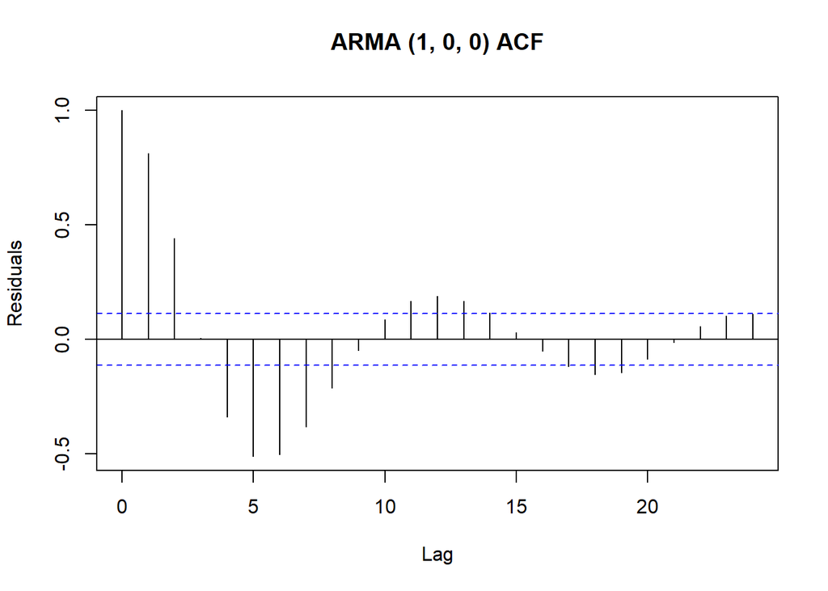

```r
# plot the ACFs
acf(arma_1_0$residuals, main = "ARMA (1, 0, 0) ACF",
     ylab = "Residuals")
```

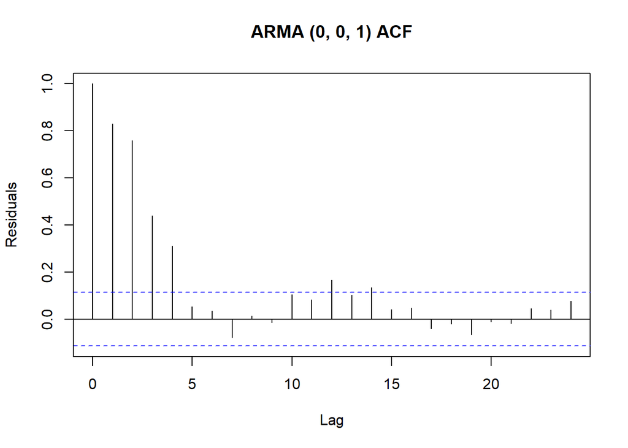

```r
acf(arma_0_1$residuals, main = "ARMA (0, 0, 1) ACF",
     ylab = "Residuals")
```

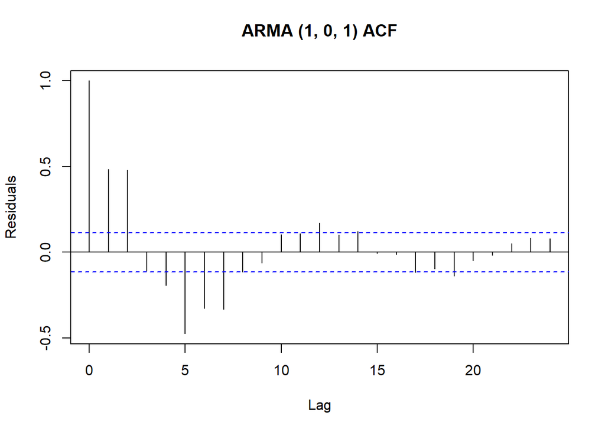

```r
acf(arma_1_1$residuals, main = "ARMA (1, 0, 1) ACF",
     ylab = "Residuals")
```

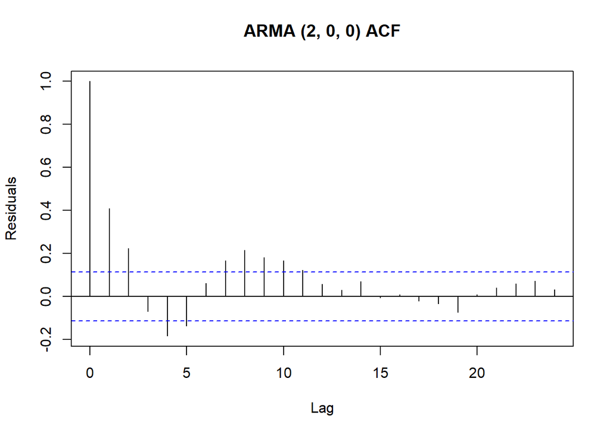

```r
acf(arma_2_0$residuals, main = "ARMA (2, 0, 0) ACF",
     ylab = "Residuals")
```

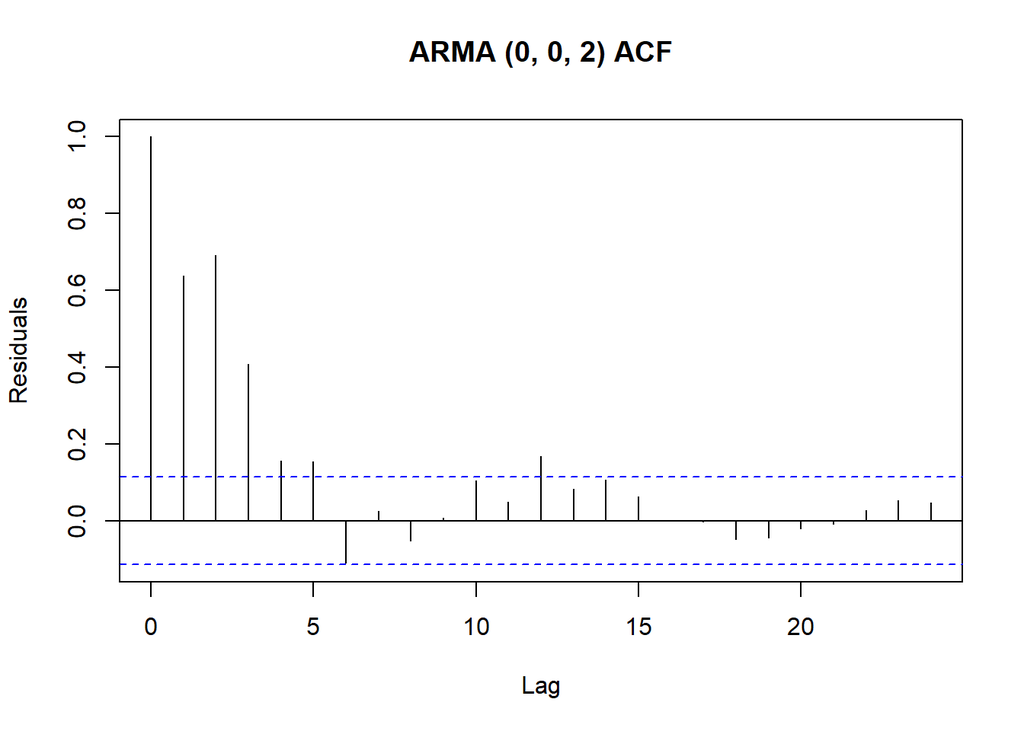

```r
acf(arma_0_2$residuals, main = "ARMA (0, 0, 2) ACF",
     ylab = "Residuals")
```

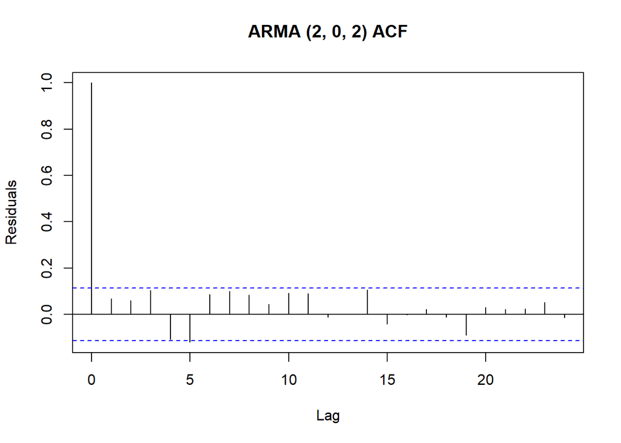

```r
acf(arma_2_2$residuals, main = "ARMA (2, 0, 2) ACF",
     ylab = "Residuals")
```

Based on the residual plots, all of the models seem to have innovations that show time series behavior. However, model 6’s (ARMA(2,2)) ACF plot shows minimal significant correlations, indicating this model’s innovations may not have a time series behavior.

# Question 5: DW Tests and LB Tests

```r
# make linear regression models for DW to work then run the test

lm_1_0 = lm(arma_1_0$residuals~1)
dw_1_0 = dwtest(lm_1_0)
dw_1_0_stat = dw_1_0$stat
dw_1_0_pval = dw_1_0$p.value

lm_0_1 = lm(arma_0_1$residuals~1)
dw_0_1 = dwtest(lm_0_1)
dw_0_1_stat = dw_0_1$stat
dw_0_1_pval = dw_0_1$p.value

lm_1_1 = lm(arma_1_1$residuals~1)
dw_1_1 = dwtest(lm_1_1)
dw_1_1_stat = dw_1_1$stat
dw_1_1_pval = dw_1_1$p.value


lm_2_0 = lm(arma_2_0$residuals~1)
dw_2_0 = dwtest(lm_2_0)
dw_2_0_stat = dw_2_0$stat
dw_2_0_pval = dw_2_0$p.value

lm_0_2 = lm(arma_0_2$residuals~1)
dw_0_2 = dwtest(lm_0_2)
dw_0_2_stat = dw_0_2$stat
dw_0_2_pval = dw_0_2$p.value

lm_2_2 = lm(arma_2_2$residuals~1)
dw_2_2 = dwtest(lm_2_2)
dw_2_2_stat = dw_2_2$stat
dw_2_2_pval = dw_2_2$p.value
```

```r
# LJ Tests

lb_1_0 = Box.test(arma_1_0$residuals, type = "Ljung-Box", lag = 10)
lb_1_0_stat = lb_1_0$statistic
lb_1_0_pval = lb_1_0$p.value

lb_0_1 = Box.test(arma_0_1$residuals, type = "Ljung-Box", lag = 10)
lb_0_1_stat = lb_0_1$statistic
lb_0_1_pval = lb_0_1$p.value

lb_1_1 = Box.test(arma_1_1$residuals, type = "Ljung-Box", lag = 10)
lb_1_1_stat = lb_1_1$statistic
lb_1_1_pval = lb_1_1$p.value


lb_2_0 = Box.test(arma_2_0$residuals, type = "Ljung-Box", lag = 10)
lb_2_0_stat = lb_2_0$statistic
lb_2_0_pval = lb_2_0$p.value

lb_0_2 = Box.test(arma_0_2$residuals, type = "Ljung-Box", lag = 10)
lb_0_2_stat = lb_0_2$statistic
lb_0_2_pval = lb_0_2$p.value

lb_2_2 = Box.test(arma_2_2$residuals, type = "Ljung-Box", lag = 10)
lb_2_2_stat = lb_2_2$statistic
lb_2_2_pval = lb_2_2$p.value
```

```r
# Extract AICs and BICs

aic_1_0 = AIC(arma_1_0)
aic_0_1 = AIC(arma_0_1)
aic_1_1 = AIC(arma_1_1)
aic_2_0 = AIC(arma_2_0)
aic_0_2 = AIC(arma_0_2)
aic_2_2 = AIC(arma_2_2)

bic_1_0 = BIC(arma_1_0)
bic_0_1 = BIC(arma_0_1)
bic_1_1 = BIC(arma_1_1)
bic_2_0 = BIC(arma_2_0)
bic_0_2 = BIC(arma_0_2)
bic_2_2 = BIC(arma_2_2)
```

```r
# Create table

results = data.frame(
  Order = c("(1,0)", "(0,1)", "(1,1)", "(2,0)", "(0,2)", "(2,2)"),
  DW_stat = c(dw_1_0_stat, dw_0_1_stat, dw_1_1_stat, dw_2_0_stat, dw_0_2_stat, dw_2_2_stat),
  DW_pval = c(dw_1_0_pval, dw_0_1_pval, dw_1_1_pval, dw_2_0_pval, dw_0_2_pval, dw_2_2_pval),
  LJ_stat = c(lb_1_0_stat, lb_0_1_stat, lb_1_1_stat, lb_2_0_stat, lb_0_2_stat, lb_2_2_stat),
  LJ_pval = c(lb_1_0_pval, lb_0_1_pval, lb_1_1_pval, lb_2_0_pval, lb_0_2_pval, lb_2_2_pval),
  AIC = c(aic_1_0, aic_0_1, aic_1_1, aic_2_0, aic_0_2, aic_2_2),
  BIC = c(bic_1_0, bic_0_1, bic_1_1, bic_2_0, bic_0_2, bic_2_2)
)

results
```

```
##   Order   DW_stat      DW_pval   LJ_stat     LJ_pval       AIC       BIC
## 1 (1,0) 0.3757154 5.881569e-45 509.05217 0.000000000  844.2931  855.3642
## 2 (0,1) 0.3346218 3.730222e-47 472.82437 0.000000000 1090.5417 1101.6128
## 3 (1,1) 1.0340435 3.789389e-17 296.93058 0.000000000  603.2422  618.0037
## 4 (2,0) 1.1751648 5.413862e-13 124.70503 0.000000000  432.7265  447.4879
## 5 (0,2) 0.7196169 1.076609e-28 337.86648 0.000000000  802.4343  817.1958
## 6 (2,2) 1.8569778 1.085094e-01  24.08623 0.007374758  362.3761  384.5182
```

## Question 6: Which Model Gives Best Result in Terms of White Noise

Based on the DW test stat, only model 6 (ARMA(2,2)) has a stat close to 2, indicating little to no autocorrelation. Based on AIC and BIC, model 6 also has the lowest values compared to the other models, indicating a better fit. According to the LJ test results, all of the models have p-values less than 0.05, indicating that the residuals are autocorrelated. However, model 6 has the highest p-value, potentially indicating that there’s less autocorrelation in it’s residuals and the residuals are closer to resembling white noise compared to the other models. Therefore, model 6 will give the best results with the residuals being close to white noise based on AIC, BIC, and the limited amount of autocorrelation found from the DW test.

## Question 7: Bootstrap Residuals

```r
# Bootstrap lin reg residuals

set.seed(44)

resids_bsp = bld.mbb.bootstrap(model$residuals, n = 500)

# Bootstrap ARMA coefficients for ARMA(1, 0, 1)

ar1_coefs = numeric(500)
ma1_coefs = numeric(500)

# Loop through each bootstrap, fit model, and store
for (i in 1:500) {
  tmp = arima(resids_bsp[[i]], order = c(1, 0, 1))

  ar1_coefs[i] = tmp$coef["ar1"]
  ma1_coefs[i] = tmp$coef["ma1"]
}
```

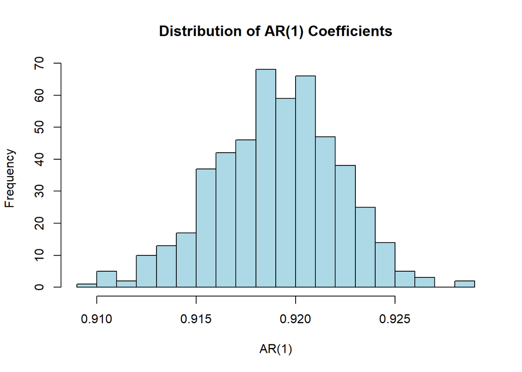

```r
hist(ar1_coefs, main = "Distribution of AR(1) Coefficients",
     xlab = "AR(1)",
     col = "Light Blue",
     breaks = 20)
```

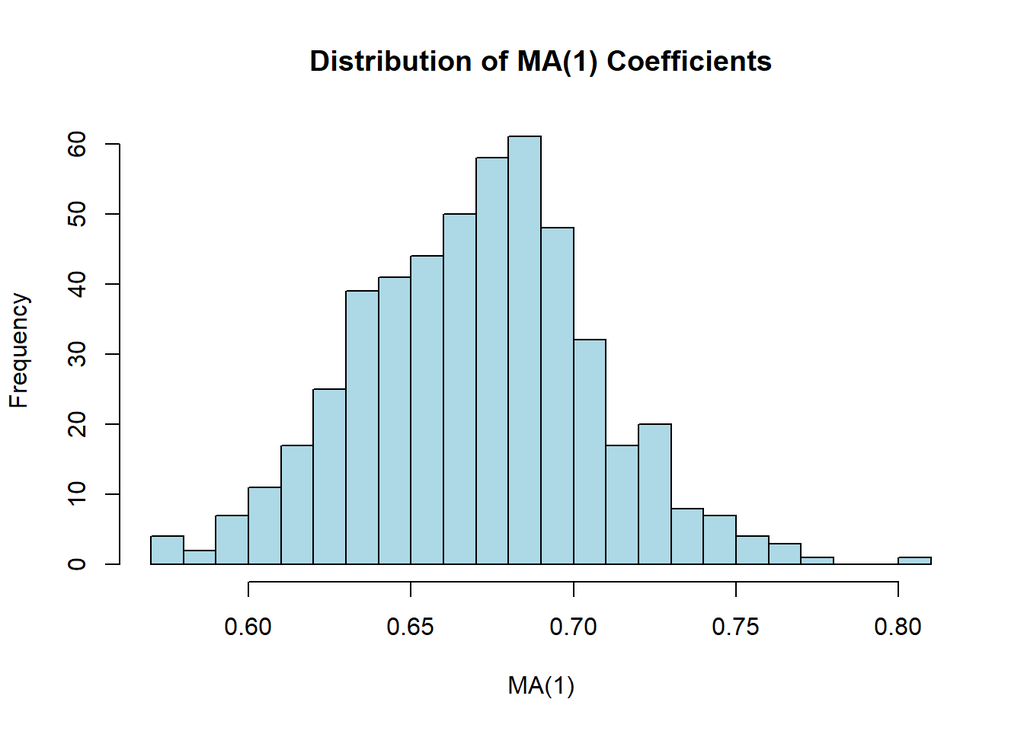

```r
hist(ma1_coefs, main = "Distribution of MA(1) Coefficients",
     xlab = "MA(1)",
     col = "Light Blue",
     breaks = 20)
```

The coefficients resemble Normal distributions due to the bell shapes. With 500 bootstrap samples (much larger than n=30), the Central Limit Theorem indicates that the distribution of the coefficients will tend to normality as the sample size increases.

## Question 8: Bootstrapped Confidence Intervals

```r
# CI for bootstrapped ARMA(1,1) model
ar1_ci <- quantile(ar1_coefs, c(0.025, 0.975))
ma1_ci <- quantile(ma1_coefs, c(0.025, 0.975))

print("Bootstrapped ARMA(1,1) Confidence Intervals")
```

```
## [1] "Bootstrapped ARMA(1,1) Confidence Intervals"
```

```r
cat("Bootstrapped 95% CI for AR(1): ", ar1_ci, "\n")
```

```
## Bootstrapped 95% CI for AR(1):  0.9128133 0.9246364
```

```r
cat("Bootstrapped 95% CI for MA(1): ", ma1_ci, "\n")
```

```
## Bootstrapped 95% CI for MA(1):  0.6003456 0.7438013
```

```r
# CI for original ARMA(1,1) model
ci2 <- confint(arma_1_1)

print("Original ARMA(1,1) Confidence Intervals")
```

```
## [1] "Original ARMA(1,1) Confidence Intervals"
```

```r
cat("95% CI for AR(1): ", ci2["ar1", ], "\n")
```

```
## 95% CI for AR(1):  0.8682903 0.959134
```

```r
cat("95% CI for MA(1): ", ci2["ma1", ], "\n")
```

```
## 95% CI for MA(1):  0.6999069 0.8066302
```